# Class 8: Politically Violent Activity

Election-related violence

[Dr. Michael C. Zeller](https://michaelzeller.de)

# Opening notes

[Open Sticker](https://tenor.com/view/open-gif-14209777)from [Open Stickers](https://tenor.com/search/open-stickers)

## Presentation groups

Presentations line-up

| Date | Presenters | Method |
| --- | --- | --- |

# Election-related violence

- Starter questions
- Harbers, Richetta, and van Wingerden (2022)
  - research design
  - analyses:
    - DV: turnout
    - DV: incumbent vote
  - conclusions

[On Election Night Dont Be Silent GIF](https://tenor.com/view/on-election-night-dont-be-silent-dont-be-violent-silence-violence-gif-18999252)from [On Election Night GIFs](https://tenor.com/search/on+election+night-gifs)

## Starter questions

**What actors might strategically use violence before or during an election? Why?**

**Can you think of any cases of election-related violence?**

## Harbers, Richetta, and van Wingerden (2022) - concepts

> electoral violence (p. 3): “coercion directed towards actors and/or objects during the electoral cycle … part of a menu of electoral manipulation, which includes threats and coercion targeting voters, candidates and officials involved in the process”
- **intra-systemic violence**
  - “try to win under the existing system”
  - “suppress or drown out the voices of political opponents”
- **anti-systemic violence**
  - “burn down the house and alter the status quo”
  - “depress participation as much as possible in order to undermine the legitimacy of the election”

## Harbers, Richetta, and van Wingerden (2022) - concepts

- **intra-systemic violence**
  - “try to win under the existing system”
  - “suppress or drown out the voices of political opponents”
- **anti-systemic violence**
  - “burn down the house and alter the status quo”
  - “depress participation as much as possible in order to undermine the legitimacy of the election”
- examples from cases? any difference in the *form* of violence? applicable beyond modern democracies? (e.g., KKK, Wilson, and *The Birth of a Nation*)

## Harbers, Richetta, and van Wingerden (2022) - concepts

- **intra-systemic violence**
- **anti-systemic violence**
- examples from cases? any difference in the *form* of violence?
  - intra-systemic: riots or group clashes between party supporters and violent attacks on candidates, politicians or voters. … ‘booth capture’, where armed goons take over polling places
  - anti-systemic: coercion of or threats against candidates, voters, poll workers or security, as well as destruction of election infrastructure

## intra-systemic violence (left) and anti-systemic violence (right) in India, 1985-2008

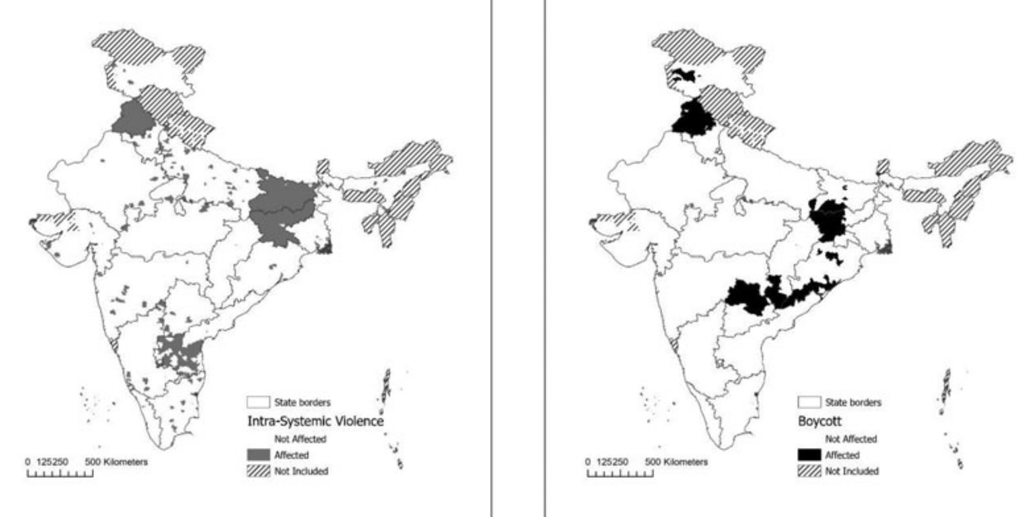

## Harbers, Richetta, and van Wingerden (2022) - design

- research aim: looking at *sub-national election-related violence in India*: what effect on electoral outcomes (DVs: turnout, incumbent vote percentage) does violence before elections (IV) have?
- Method: series of fixed-effects and Poisson regression models
  - $\hookrightarrow$ fixed-effects - intercept of model varies across units/cases to control for unvarying attributes of specific units/cases
  - $\hookrightarrow$ Poisson - often used to model ‘count’ data
- Data (collection procedure detailed on p. 8):
  - Times of India (ToI) new reports, *sub-national* elections
  - Unit of analysis/case: constituency-year
  - coded: violence intra-systemic or part of armed group’s tactic

## Reg table, DV: turnout

what findings can you pick out?

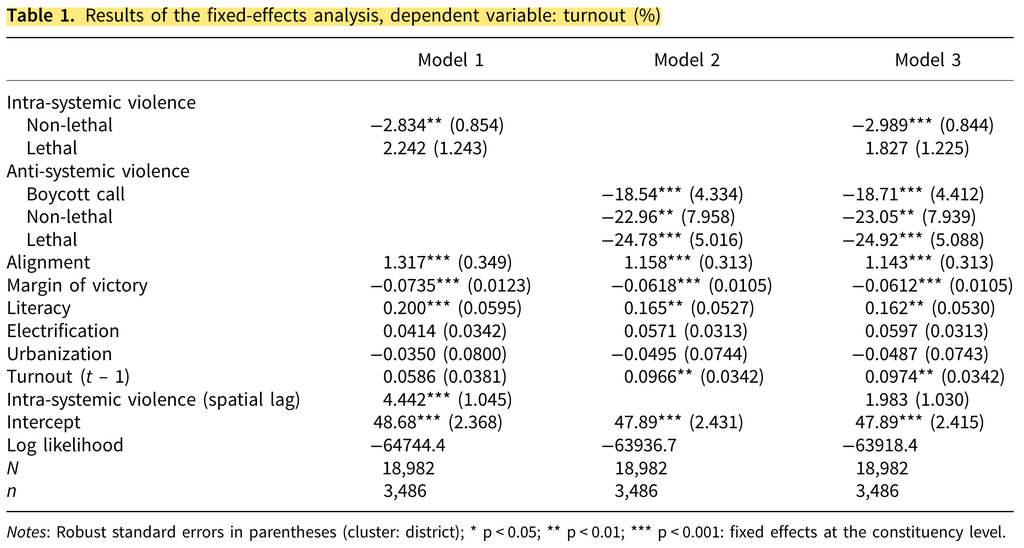

## Reg table, DV: turnout

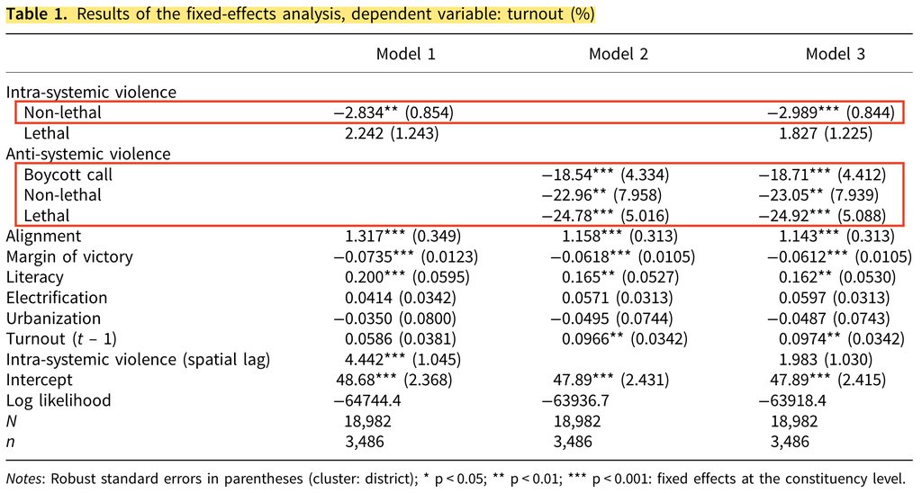

- intra-systemic and anti-systemic violence are negatively associated with turnout (in separate and combined models)
- intra-systemic violence, the negative effect emerges only for non-lethal events (88.2% of all intra-systemic violence in data). Coefficient for lethal events is not significant.
- effect of anti-systemic violence on turnout is stronger than the effect of intra-systemic violence (Model 3)

## Reg table, DV: incumbent vote

what findings can you pick out?

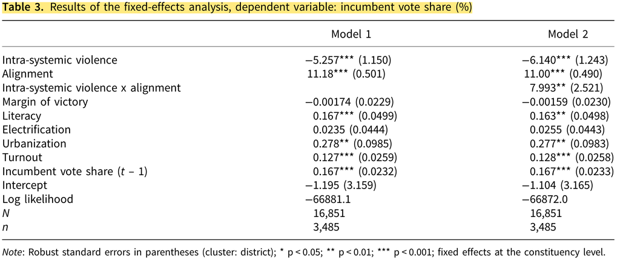

## Reg table, DV: incumbent vote

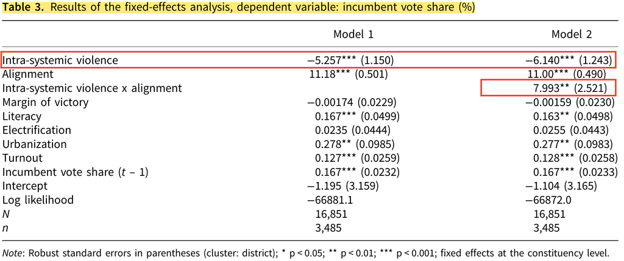

## Harbers, Richetta, and van Wingerden (2022) - conclusions

- violence decreases turnout but that the **effect is larger for anti-systemic violence**
- intra-systemic violence appears intended to **selectively depress turnout** among opposition supporters
- **anti-systemic violence** “extremely effective in terms of keeping voters away from the polls and thus discrediting the electoral results due to low participation rates”
  - ethics question: qualms about reporting this finding?
- open data on subnational violence: Zhukov, Davenport, and Kostyuk (2019)

**how should states respond to electoral violence?**

# Poll: election-related violence

[figure not shown]

Take the survey at **https://forms.gle/aFgvV521ZFGC8Rih9**

Questions about groups: (1) Does the group’s violence increase around elections? (2) How is the group’s violence connected to elections? (3) Has the group intimidated/targeted voters? (4) Has the group intimidated/targeted candidates/office-holders?

[interactive chart not shown]

Does the group’s violence increase around elections?

[interactive chart not shown]

## Group responses - election violence

How is the group’s violence connected to elections?

[interactive chart not shown]

## Group responses - election targeting

group intimidated/targeted voters?

[interactive chart not shown]

group intimidated/targeted candidates/office-holders?

[interactive chart not shown]

# Back to Violence / Nonviolence

- background: Chenoweth and Stephan (2011)
- Kudelia (2018) and the case of Euromaidan in Ukraine
  - a puzzling case?
  - productive and counter-productive effects of violence
  - findings
- concluding question

[Violence Bun GIF](https://tenor.com/view/violence-bun-bunny-violent-rabbit-gif-9356306307403535357)from [Violence GIFs](https://tenor.com/search/violence-gifs)

## Background: study of Chenoweth and Stephan (2011)

[figure not shown]

- research aim: determine relative success of nonviolent (‘civil resistance’ - Gene Sharp) or violent resistance
- cases of violent and non-violent campaigns between 1900 and 2006: 323 cases

## Background: study of Chenoweth and Stephan (2011)

[figure not shown]

- cases of violent and non-violent campaigns between 1900 and 2006: 323 cases
  - inferential stats analysis of data
  - new dataset: Dahl et al. (2025)
  - three case studies: Philippine people power movement (1983–86), FALANTIL struggles for East Timor independence (1988–99), and Burmese civil resistance (1988–1990)
- non-violent more than twice as likely to achieve full or partial success compared to violent cases

## Background: study of Chenoweth and Stephan (2011)

Pay attention to the mechanisms that Prof. Chenoweth specifies in her brief explanation

[video not shown]

## Background: study of Chenoweth and Stephan (2011)

Pay attention to the mechanisms that Prof. Chenoweth specifies in her brief explanation

- nonviolent campaigns are better at eliciting broad and diverse support
- nonviolent campaigns create more defections among the opposition
- nonviolent campaigns have a broader set of tactics at their disposal
- nonviolent campaigns often maintain discipline even in the face of escalating oppression

## Kudelia (2018) - refining Chenoweth and Stephan (2011)

- Ukraine’s Euromaidan
  - what’s going on in this case?
    - Yanukovych’s regime: semi-authoritarian
- violent protests occurred…
  - **but** accounted for just 12 percent of all protests
  - **yet** concentrated in final month (Jan.-Feb. 2014) and in Kyiv

## Kudelia (2018) - refining Chenoweth and Stephan (2011)

- Ukraine’s Euromaidan
  - what’s going on in this case?
    - Yanukovych’s regime: semi-authoritarian
- violent protests occurred…
  - **but** accounted for just 12 percent of all protests
  - **yet** concentrated in final month (Jan.-Feb. 2014) and in Kyiv

> “The success of violent protest tactics in Ukraine’s case, **puzzling** from the standpoint of recent findings, has received no systematic, theoretically-driven scholarly treatment.”
- violent tactics effective - is it puzzling? (cf. Chenoweth and Stephan 2011)

## (empirically, theoretically) puzzling or not…

- Kudelia (2018) - within-case qualitative process tracing of “actors’ choices using a rationalist theoretical”
  - rationalist = strategic choice rather than spontaneous reaction

## (counter-)productive effects of violence - Kudelia (2018)

- violence **counter-productive**
  1. alienate current and potential supporters
  2. provoke a coercive response
  3. dampen international support for protests
- violence **productive**
  1. participatory character of protest violence
  2. embeddedness of violent groups and practices in a generally non-violent movement (*radical flanks*)
  3. capacity and willingness of violent activists to escalate beyond the cost-tolerance threshold of the regime
     - i.e., how much will regime tolerate? will it offer concessions?

## Kudelia (2018) - findings

- violence complementing **already** and **continuing** high mobilisation is effective in making regime more sensitive to protest costs
- “a regime’s repressive escalation may decrease net participation costs by broadening support for militants among rank-and-file protesters and outside sympathizers”
- two-tiered orgs.: a violent vanguard and a non-violent base
  - strengthens the leverage of moderate opposition elites in bargaining with the regime
  - when used in conjunction with non-violent actions in response to intensifying repression, it **may deter** the regime **or even tip** the balance of power against it.
- your thoughts on these findings?

# Open data - Big Allied and Dangerous

- Visualisation
- Explanatory note

Criminal Activity and Conflict Intensity of Insurgent Organisations

[interactive chart not shown]

This scatter plot shows the relationship between criminal activity and conflict intensity among insurgent organisations in the [Big Allied and Dangerous Dataset](https://www.start.umd.edu/using-baad) (BAAD2). Each bubble is an organisation in a specific year. The x-axis shows a criminal activity score, which measures how many different forms of criminal financing an organisation uses, including drug trafficking, extortion, kidnapping, robbery, and smuggling. The y-axis shows the number of battle-related deaths associated with the conflict. Bubble size reflects organisational size; colours show different ideological types. By hovering over individual bubbles, you can view additional information about the organisation, the country in which it operated, the year of observation, and whether it exercised territorial control.

# Concluding discussion

Relationship across a movement:

**how do (or should) nonviolent actors deal with violent actors/groups within their movement (‘radical flanks’)? Infighting or solidarity?**

# Any questions, concerns, feedback for this class?

Anonymous feedback here: https://forms.gle/NfF1pCfYMbkAT3WP6

Alternatively, please send me an email: m.zeller@lmu.de

Questions about groups next meeting: (1) How does the group’s use of violence evolve over time? (2) How are major acts of violence perpetrated? (3) Does the group show restraint in choosing targets? (4) Is the group’s restraint more strategic or moral? (5) Does the group have internal mechanisms to prevent uncontrolled violence? (6) Does the group escalate violence in response to state actions?

## References

Chenoweth, Erica, and Maria J. Stephan. 2011. *Why Civil Resistance Works: The Strategic Logic of Nonviolent Conflict*. New York: Columbia University Press.

Dahl, Marianne, Sirianne Dahlum, Hanne Fjelde, Haakon Gjerløw, Carl Henrik Knutsen, Carina Strøm-Sedgwick, and Tore Wig. 2025. “Mass Mobilization in the Modern Era: Introducing the Opposition Movements and Groups (OMG) Dataset, 1789–2019.” *Comparative Political Studies*, August, 00104140251369330. https://doi.org/10.1177/00104140251369330.

Harbers, Imke, Cécile Richetta, and Enrike van Wingerden. 2022. “Shaping Electoral Outcomes: Intra- and Anti-systemic Violence in Indian Assembly Elections.” *British Journal of Political Science*, October, 1–17. https://doi.org/10.1017/S0007123422000345.

Kudelia, Serhiy. 2018. “When Numbers Are Not Enough: The Strategic Use of Violence in Ukraine’s 2014 Revolution.” *Comparative Politics* 50 (4): 501–21.

Zhukov, Yuri M, Christian Davenport, and Nadiya Kostyuk. 2019. “Introducing xSub: A New Portal for Cross-National Data on Subnational Violence.” *Journal of Peace Research* 56 (4): 604–14. https://doi.org/10.1177/0022343319836697.